# Часть 1: Задания, решаемые без использования Python

## Задание 1

Исследуйте систему векторов на линейную зависимость или независимость без использования Python (вручную):

а1 = (1, 8, -1) а2 = (-2, 3, 3) a3 = (4, -11, 9)

Подробно распишите решение, а в итоге сделайте вывод про то, являются ли векторы зависимыми или независимыми

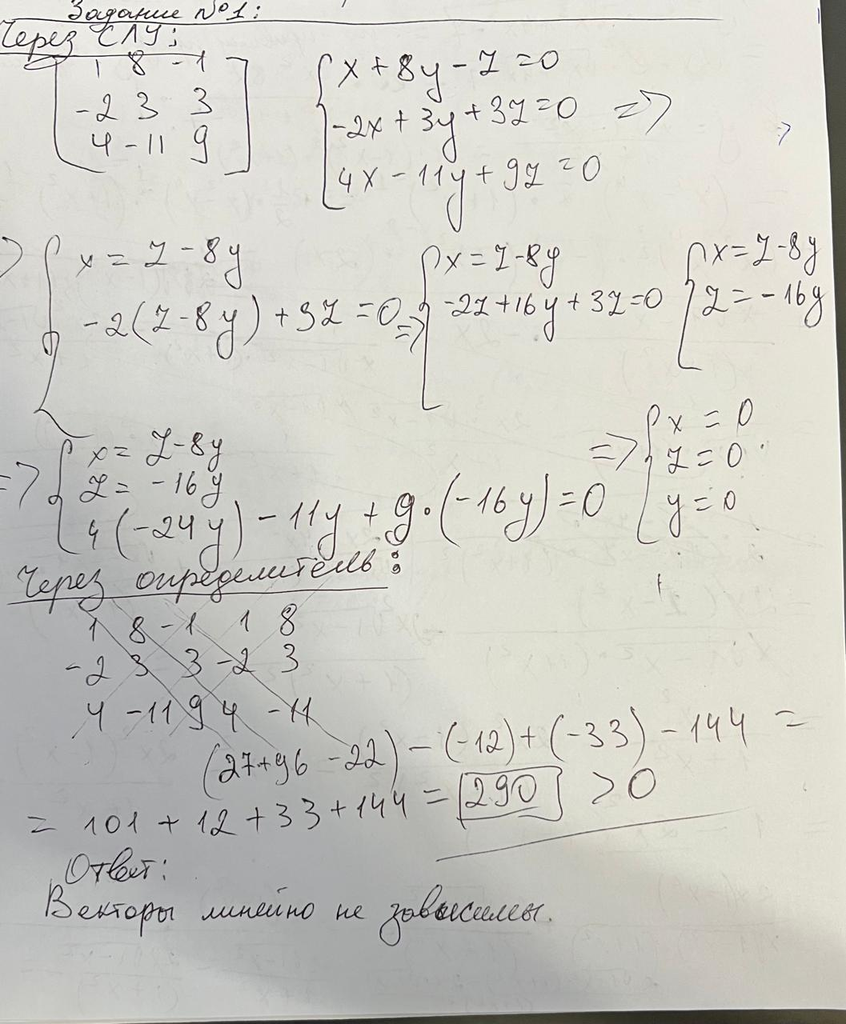

*Вывод:*

Векторы $a_1 = (1, 8, -1)$, $a_2 = (-2, 3, 3)$, $a_3 = (4, -11, 9)$ линейно независимы

## Задание 2

При каких значениях параметра a система является линейно зависимой?  
Найдите решение без использования Python (вручную)

a1 = (1; 0; 2; -3),  
a2 = (2; 2; -4; a),  
a3 = (3; 1; 2; -5)

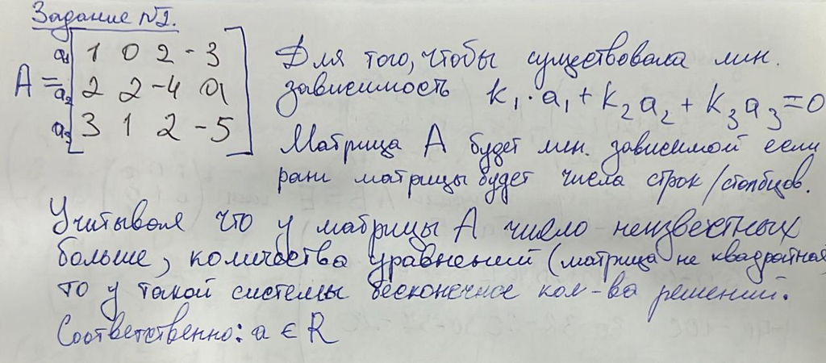

## Задание 3

Выразите определитель матрицы. Найдите решение без использования Python (вручную)

\begin{vmatrix} 1 & -1 & a & -1 \\ -1 & -2 & b & -1 \\ -2 & 0 & c & 1 \\ 0 & 1 & d & 0 \end{vmatrix}

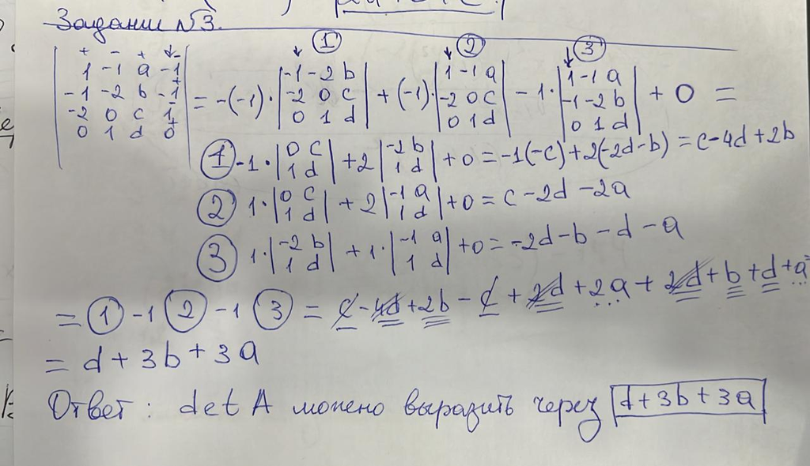

## Задание 4

Найдите значения параметров a, b и c, при которых матрицы A и B являются обратными. Найдите решение без использования Python (вручную).

$A=\left(\begin{array}{ccc} a & -2 & -1 \\ -15 & b+20 & 12 \\ 10 & -19 & 2 c \end{array}\right), B=\left(\begin{array}{rrr} -4 & 3 & 5 \\ 0 & 2 & 3 \\ -5 & -1 & -1 \end{array}\right)$

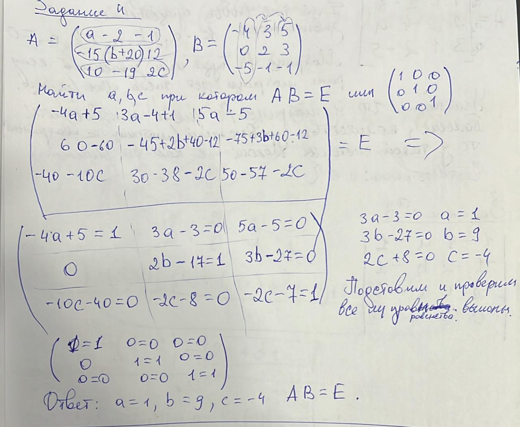

## Задание 5

Найдите собственные векторы и собственные значения матрицы. Найдите решение без использования Python (вручную).

$\left(\begin{array}{rrr}4 & 0 & -1 \\ 2 & 2 & 1 \\ -1 & 0 & 4\end{array}\right)$

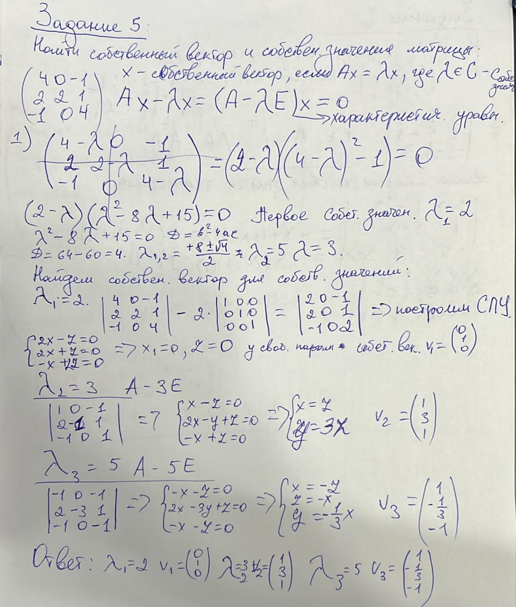

## Задание 6

Найдите сумму сингулярных чисел для матрицы:

$A=\left(\begin{array}{ccc}-2 & 0 & 1 \\ 0 & -2 & 1 \\ 1 & 1 & -1\end{array}\right)$

Найдите решение без использования Python (вручную).

*Найдём сумму сингулярных чисел для матрицы $A$*

Сингулярные числа матрицы $ A $ — это квадратные корни собственных значений матрицы $ A^T A $ (или $ AA^T $)

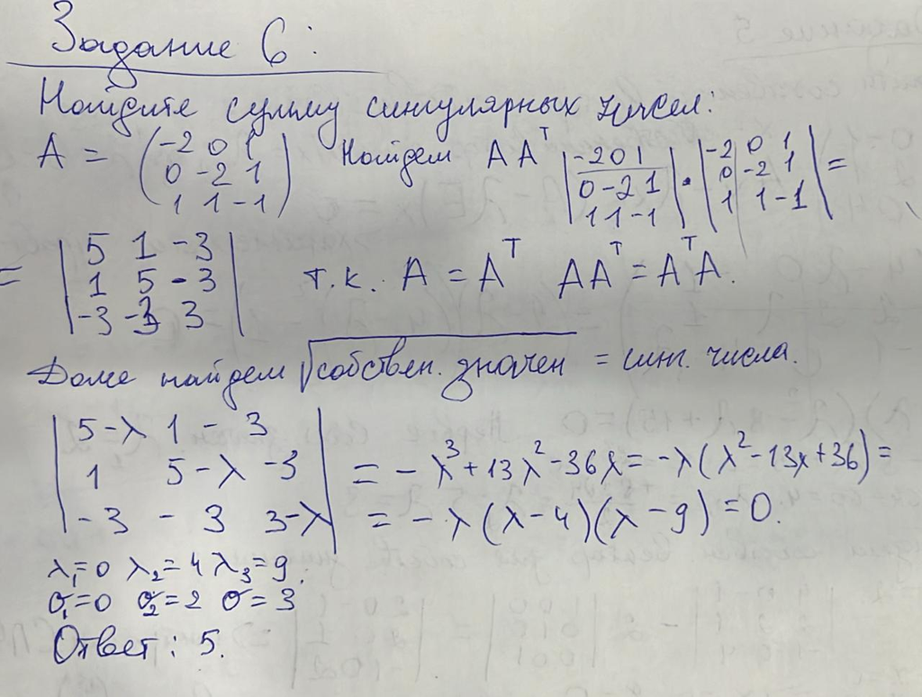

*Ответ:* Сумма сингулярных чисел матрицы $A$ равна $5$.

# Часть 2: Задания, решаемые с помощью Python

Даны данные об аренде велосипедов.

Описание переменных:

- season: 1 - весна, 2 - лето, 3 - осень, 4 - зима
- yr: 0 - 2011, 1 - 2012
- mnth: месяц, от 1 до 12
- holiday: 0 - нет праздника, 1 - есть праздник
- weekday: день недели, от 0 до 6
- workingday: 0 - нерабочий день, 1 - рабочий день
- weathersit: оценка благоприятности погоды от 1 (чистый, ясный день) до 4 (ливень, туман)
- temp: температура в Цельсиях
- atemp: температура по ощущениям в Цельсиях
- hum: влажность
- windspeed(mph): скорость ветра в милях в час
- windspeed(ms): скорость ветра в метрах в секунду
- cnt: количество арендованных велосипедов (это целевой признак, его мы будем предсказывать)

## Задание 7

Загрузите данные. Изучите, есть ли в них пропущенные значения? Распишите решение с помощью кода на языке Python и напишите текстом интерпретацию полученного вывода.

```python
import pandas as pd
```

```python
data = pd.read_csv("bikes_rent.csv")
data.head()
```

|  | season | yr | mnth | holiday | weekday | workingday | weathersit | temp | atemp | hum | windspeed(mph) | windspeed(ms) | cnt |
| --- | --- | --- | --- | --- | --- | --- | --- | --- | --- | --- | --- | --- | --- |
| 0 | 1 | 0 | 1 | 0 | 6 | 0 | 2 | 14.110847 | 18.18125 | 80.5833 | 10.749882 | 4.805490 | 985 |
| 1 | 1 | 0 | 1 | 0 | 0 | 0 | 2 | 14.902598 | 17.68695 | 69.6087 | 16.652113 | 7.443949 | 801 |
| 2 | 1 | 0 | 1 | 0 | 1 | 1 | 1 | 8.050924 | 9.47025 | 43.7273 | 16.636703 | 7.437060 | 1349 |
| 3 | 1 | 0 | 1 | 0 | 2 | 1 | 1 | 8.200000 | 10.60610 | 59.0435 | 10.739832 | 4.800998 | 1562 |
| 4 | 1 | 0 | 1 | 0 | 3 | 1 | 1 | 9.305237 | 11.46350 | 43.6957 | 12.522300 | 5.597810 | 1600 |

```python
data.isnull().sum()
```

```
season            0
yr                0
mnth              0
holiday           0
weekday           0
workingday        0
weathersit        0
temp              0
atemp             0
hum               0
windspeed(mph)    0
windspeed(ms)     0
cnt               0
dtype: int64
```

В данном датасете нет пропущенных значений в полях

## Задание 8

Исследуем данные на наличие линейной зависимости между столбцами. Найдите ранг матрицы данных. Сравните его с количеством столбцов, сделайте вывод. Если линейная зависимость есть - напишите, между какими столбцами и удалите один из них.

Распишите решение с помощью кода на языке Python и напишите текстом интерпретацию полученного вывода.

```python
import numpy as np
```

```python
# рассчитаем корреляцию между числовыми столбцами
correlation_matrix = data.corr()
print('Корреляционная матрица: ')
correlation_matrix
```

```
Корреляционная матрица:
```

|  | season | yr | mnth | holiday | weekday | workingday | weathersit | temp | atemp | hum | windspeed(mph) | windspeed(ms) | cnt |
| --- | --- | --- | --- | --- | --- | --- | --- | --- | --- | --- | --- | --- | --- |
| season | 1.000000 | -0.001844 | 0.831440 | -0.010537 | -0.003080 | 0.012485 | 0.019211 | 0.334315 | 0.342876 | 0.205445 | -0.229046 | -0.229046 | 0.406100 |
| yr | -0.001844 | 1.000000 | -0.001792 | 0.007954 | -0.005461 | -0.002013 | -0.048727 | 0.047604 | 0.046106 | -0.110651 | -0.011817 | -0.011817 | 0.566710 |
| mnth | 0.831440 | -0.001792 | 1.000000 | 0.019191 | 0.009509 | -0.005901 | 0.043528 | 0.220205 | 0.227459 | 0.222204 | -0.207502 | -0.207502 | 0.279977 |
| holiday | -0.010537 | 0.007954 | 0.019191 | 1.000000 | -0.101960 | -0.253023 | -0.034627 | -0.028556 | -0.032507 | -0.015937 | 0.006292 | 0.006292 | -0.068348 |
| weekday | -0.003080 | -0.005461 | 0.009509 | -0.101960 | 1.000000 | 0.035790 | 0.031087 | -0.000170 | -0.007537 | -0.052232 | 0.014282 | 0.014282 | 0.067443 |
| workingday | 0.012485 | -0.002013 | -0.005901 | -0.253023 | 0.035790 | 1.000000 | 0.061200 | 0.052660 | 0.052182 | 0.024327 | -0.018796 | -0.018796 | 0.061156 |
| weathersit | 0.019211 | -0.048727 | 0.043528 | -0.034627 | 0.031087 | 0.061200 | 1.000000 | -0.120602 | -0.121583 | 0.591045 | 0.039511 | 0.039511 | -0.297391 |
| temp | 0.334315 | 0.047604 | 0.220205 | -0.028556 | -0.000170 | 0.052660 | -0.120602 | 1.000000 | 0.991702 | 0.126963 | -0.157944 | -0.157944 | 0.627494 |
| atemp | 0.342876 | 0.046106 | 0.227459 | -0.032507 | -0.007537 | 0.052182 | -0.121583 | 0.991702 | 1.000000 | 0.139988 | -0.183643 | -0.183643 | 0.631066 |
| hum | 0.205445 | -0.110651 | 0.222204 | -0.015937 | -0.052232 | 0.024327 | 0.591045 | 0.126963 | 0.139988 | 1.000000 | -0.248489 | -0.248489 | -0.100659 |
| windspeed(mph) | -0.229046 | -0.011817 | -0.207502 | 0.006292 | 0.014282 | -0.018796 | 0.039511 | -0.157944 | -0.183643 | -0.248489 | 1.000000 | 1.000000 | -0.234545 |
| windspeed(ms) | -0.229046 | -0.011817 | -0.207502 | 0.006292 | 0.014282 | -0.018796 | 0.039511 | -0.157944 | -0.183643 | -0.248489 | 1.000000 | 1.000000 | -0.234545 |
| cnt | 0.406100 | 0.566710 | 0.279977 | -0.068348 | 0.067443 | 0.061156 | -0.297391 | 0.627494 | 0.631066 | -0.100659 | -0.234545 | -0.234545 | 1.000000 |

```python
# найдем ранг матрицы
matrix_rank = np.linalg.matrix_rank(data.select_dtypes(include=[np.number]))
print("Ранг матрицы:", matrix_rank)
```

```
Ранг матрицы: 12
```

```python
# cравним ранг с количеством столбцов
num_columns = data.select_dtypes(include=[np.number]).shape[1]
print("Количество столбцов:", num_columns)
```

```
Количество столбцов: 13
```

```python
# вывод по линейной зависимости
if matrix_rank < num_columns:

    print("Есть линейная зависимость между некоторыми столбцами")

    # Находим пары столбцов с высокой корреляцией (выше 0.8)
    high_correlation = correlation_matrix[
        (correlation_matrix > 0.8) & (correlation_matrix < 1.0)
    ]
    print("\nСтолбцы с высокой корреляцией:")
    display(high_correlation)

else:
    print("\nНет линейной зависимости между столбцами")
```

```
Есть линейная зависимость между некоторыми столбцами

Столбцы с высокой корреляцией:
```

|  | season | yr | mnth | holiday | weekday | workingday | weathersit | temp | atemp | hum | windspeed(mph) | windspeed(ms) | cnt |
| --- | --- | --- | --- | --- | --- | --- | --- | --- | --- | --- | --- | --- | --- |
| season | NaN | NaN | 0.83144 | NaN | NaN | NaN | NaN | NaN | NaN | NaN | NaN | NaN | NaN |
| yr | NaN | NaN | NaN | NaN | NaN | NaN | NaN | NaN | NaN | NaN | NaN | NaN | NaN |
| mnth | 0.83144 | NaN | NaN | NaN | NaN | NaN | NaN | NaN | NaN | NaN | NaN | NaN | NaN |
| holiday | NaN | NaN | NaN | NaN | NaN | NaN | NaN | NaN | NaN | NaN | NaN | NaN | NaN |
| weekday | NaN | NaN | NaN | NaN | NaN | NaN | NaN | NaN | NaN | NaN | NaN | NaN | NaN |
| workingday | NaN | NaN | NaN | NaN | NaN | NaN | NaN | NaN | NaN | NaN | NaN | NaN | NaN |
| weathersit | NaN | NaN | NaN | NaN | NaN | NaN | NaN | NaN | NaN | NaN | NaN | NaN | NaN |
| temp | NaN | NaN | NaN | NaN | NaN | NaN | NaN | NaN | 0.991702 | NaN | NaN | NaN | NaN |
| atemp | NaN | NaN | NaN | NaN | NaN | NaN | NaN | 0.991702 | NaN | NaN | NaN | NaN | NaN |
| hum | NaN | NaN | NaN | NaN | NaN | NaN | NaN | NaN | NaN | NaN | NaN | NaN | NaN |
| windspeed(mph) | NaN | NaN | NaN | NaN | NaN | NaN | NaN | NaN | NaN | NaN | NaN | 1.0 | NaN |
| windspeed(ms) | NaN | NaN | NaN | NaN | NaN | NaN | NaN | NaN | NaN | NaN | 1.0 | NaN | NaN |
| cnt | NaN | NaN | NaN | NaN | NaN | NaN | NaN | NaN | NaN | NaN | NaN | NaN | NaN |

На основе полученной корреляционной матрицы видно, что значения корреляции между некоторыми столбцами очень высоки

- temp и atemp: корреляция 0.991702 — зависимость между температурой и температурой по ощущениям.
- windspeed(mph) и windspeed(ms): корреляция 1.0 — полная зависимость, так как скорость ветра измеряется в двух единицах.

Удалим столбец windspeed(mph)

```python
del data["windspeed(mph)"]
```

## Задание 9

Выведите корреляционную матрицу оставшихся переменных.

Какая переменная сильнее всего коррелирует с целевой? Есть ли мультиколлинеарность? Между какими переменными? Если есть корреляция выше 0.9 - оставьте только 1 признак. Объясните выбор Распишите решение с помощью кода на языке Python и напишите текстом интерпретацию полученного вывода.

```python
data.corr()
```

|  | season | yr | mnth | holiday | weekday | workingday | weathersit | temp | atemp | hum | windspeed(ms) | cnt |
| --- | --- | --- | --- | --- | --- | --- | --- | --- | --- | --- | --- | --- |
| season | 1.000000 | -0.001844 | 0.831440 | -0.010537 | -0.003080 | 0.012485 | 0.019211 | 0.334315 | 0.342876 | 0.205445 | -0.229046 | 0.406100 |
| yr | -0.001844 | 1.000000 | -0.001792 | 0.007954 | -0.005461 | -0.002013 | -0.048727 | 0.047604 | 0.046106 | -0.110651 | -0.011817 | 0.566710 |
| mnth | 0.831440 | -0.001792 | 1.000000 | 0.019191 | 0.009509 | -0.005901 | 0.043528 | 0.220205 | 0.227459 | 0.222204 | -0.207502 | 0.279977 |
| holiday | -0.010537 | 0.007954 | 0.019191 | 1.000000 | -0.101960 | -0.253023 | -0.034627 | -0.028556 | -0.032507 | -0.015937 | 0.006292 | -0.068348 |
| weekday | -0.003080 | -0.005461 | 0.009509 | -0.101960 | 1.000000 | 0.035790 | 0.031087 | -0.000170 | -0.007537 | -0.052232 | 0.014282 | 0.067443 |
| workingday | 0.012485 | -0.002013 | -0.005901 | -0.253023 | 0.035790 | 1.000000 | 0.061200 | 0.052660 | 0.052182 | 0.024327 | -0.018796 | 0.061156 |
| weathersit | 0.019211 | -0.048727 | 0.043528 | -0.034627 | 0.031087 | 0.061200 | 1.000000 | -0.120602 | -0.121583 | 0.591045 | 0.039511 | -0.297391 |
| temp | 0.334315 | 0.047604 | 0.220205 | -0.028556 | -0.000170 | 0.052660 | -0.120602 | 1.000000 | 0.991702 | 0.126963 | -0.157944 | 0.627494 |
| atemp | 0.342876 | 0.046106 | 0.227459 | -0.032507 | -0.007537 | 0.052182 | -0.121583 | 0.991702 | 1.000000 | 0.139988 | -0.183643 | 0.631066 |
| hum | 0.205445 | -0.110651 | 0.222204 | -0.015937 | -0.052232 | 0.024327 | 0.591045 | 0.126963 | 0.139988 | 1.000000 | -0.248489 | -0.100659 |
| windspeed(ms) | -0.229046 | -0.011817 | -0.207502 | 0.006292 | 0.014282 | -0.018796 | 0.039511 | -0.157944 | -0.183643 | -0.248489 | 1.000000 | -0.234545 |
| cnt | 0.406100 | 0.566710 | 0.279977 | -0.068348 | 0.067443 | 0.061156 | -0.297391 | 0.627494 | 0.631066 | -0.100659 | -0.234545 | 1.000000 |

```python
data.corr()["cnt"].to_frame().sort_values(by="cnt")
```

|  | cnt |
| --- | --- |
| weathersit | -0.297391 |
| windspeed(ms) | -0.234545 |
| hum | -0.100659 |
| holiday | -0.068348 |
| workingday | 0.061156 |
| weekday | 0.067443 |
| mnth | 0.279977 |
| season | 0.406100 |
| yr | 0.566710 |
| temp | 0.627494 |
| atemp | 0.631066 |
| cnt | 1.000000 |

- Самая сильная корреляция с целевой переменной cnt: это столбцы atemp (0.631066) и temp (0.627494). Обе эти переменные связаны с температурой, причем atemp (температура по ощущениям) более сильно коррелирует с количеством арендованных велосипедов
- Также между переменными temp и atemp высокая корреляция (0.991702), что означает, что эти два признака сильно линейно зависимы. Такая ситуация является проявлением мультиколлинеарности, и чтобы ее устранить, оставим только один из этих признаков

Удалим температуру temp - с таргетом корреляция ниже

```python
del data["temp"]
```

## Задание 10

Разделите данные на предикторы и целевую переменную. Обучите модель с помощью классической линейной регрессии. Линейную регрессию необходимо реализовать без готовых библиотек.

Оцените качество модели с помощью хотя бы двух метрик качества.

Распишите решение с помощью кода на языке Python и напишите текстом интерпретацию полученного вывода.

```python
X = data.drop(columns=["cnt"])  # все переменные, кроме целевой переменной
y = data["cnt"]  # целевая переменная
```

```python
# столбец единичных значений для смещения (bias)
X = np.c_[np.ones(X.shape[0]), X]

X = np.array(X)
y = np.array(y)

# находим коэффициенты линейной регрессии
beta = np.linalg.inv(X.T @ X) @ X.T @ y
```

```python
# получаем прогнозы
y_pred = X @ beta
```

```python
# Среднеквадратичная ошибка
mse = np.mean((y - y_pred) ** 2)

# Коэффициент детерминации R^2
ss_total = np.sum((y - np.mean(y)) ** 2)
ss_residual = np.sum((y - y_pred) ** 2)
r2 = 1 - (ss_residual / ss_total)

print(f"MSE: {mse}")
print(f"R^2: {r2}")
```

```
MSE: 750791.3907028725
R^2: 0.7996636553055045
```